# Modeling Process

กระบวนการพัฒนาการเรียนรู้ของเครื่องนั้น มีลักษณะคล้ายคลึงกับการวิเคราะห์ข้อมูลเชิงสำรวจ (exploratory data analysis: EDA) กล่าวคือเป็นกระบวนการที่ไม่ทราบคำตอบหรือวิธีการดำเนินงานที่แน่นอน และมักต้องมีการดำเนินการทวนซ้ำจนกระทั่งได้ผลลัพธ์เป็นที่น่าพึงพอใจ

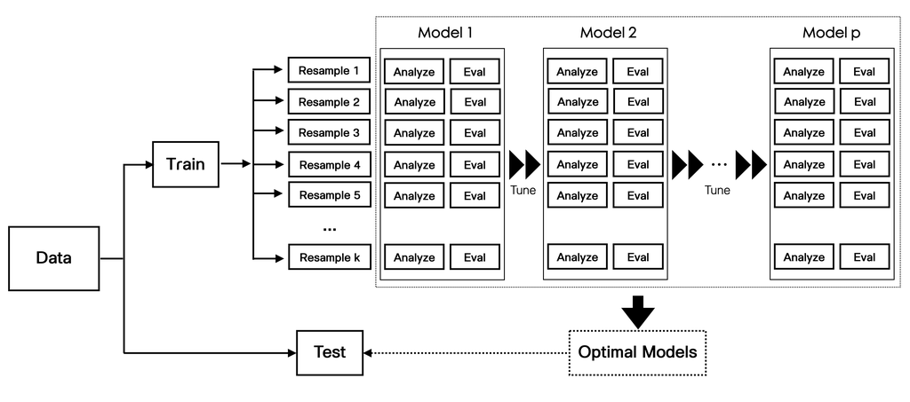

Modeling Process

จากรูปข้างต้นจะเห็นว่ากระบวนการพัฒนาการเรียนรู้ของเครื่องนั้นประกอบด้วยขั้นตอนการดำเนินการหลายขั้นตอน และมีความรู้พื้นฐานหลายอย่างที่ผู้เรียนจำเป็นต้องทราบก่อนการเรียนเนื้อหาอื่น ๆ ถัดไป บทเรียนนี้จะกล่าวถึงความรู้พื้นฐานสำคัญดังกล่าว รายละเอียดมีดังนี้

# การแบ่งข้อมูล (Data Splitting)

วัตถุประสงค์หลักในการเรียนรู้ของเครื่อง คือ การพัฒนาอัลกอริทึม $f(X)$ ที่สามารถทำนายผลลัพธ์ $Y$ ของหน่วยข้อมูลที่สนใจได้อย่างแม่นยำมากที่สุด

นอกจากนี้ผู้วิเคราะห์ยังไม่ได้สนใจเพียงแต่ความแม่นยำของการทำนายภายใต้ชุดข้อมูลที่นำมาวิเคราะห์เท่านั้น ยังสนใจความแม่นยำของการทำนายหน่วยข้อมูลที่เครื่องไม่รู้จักกล่าวคืออยู่นอกเหนือจากชุดข้อมูลที่นำมาวิเคราะห์ด้วย เรียกคุณสมบัตินี้ว่า generalizability

การจะประเมินว่าโมเดลทำนายของผู้วิเคราะห์มีคุณสมบัติ generalizability มากน้อยเพียงใด ไม่สามารถประเมินได้จากข้อมูลเพียงชุดเดียว ในการดำเนินงานจึงมีการแบ่งข้อมูลออกเป็นสองส่วน เรียกว่า ชุดข้อมูลฝึกหัด (training datset) และชุดข้อมูลทดสอบ (test dataset)

ชุดข้อมูลฝึกหัด เป็นชุดข้อมูลที่ผู้วิเคราะห์จะนำไปใช้สำหรับพัฒนาโมเดลที่ดีที่สุด โดยเริ่มตั้งแต่ขั้นตอนการคัดเลือกตัวแปรทำนาย สร้างโมเดลทำนาย ปรับแต่ง hyperparameters ของโมเดลทำนาย เปรียบเทียบและคัดเลือกชุดของโมเดลที่ดีที่สุดที่จะนำไปแข่งขันกันในชุดข้อมูลทดสอบ การเปรียบเทียบโมเดลบนชุดข้อมูลทดสอบช่วยให้ผู้วิเคราะห์พิจารณาได้ว่าโมเดลใดเป็นโมเดลที่มี generalization error ต่ำที่สุด และควรถูกเลือกไปใช้งาน

โดยปกติแล้วผู้วิเคราะห์มักแบ่งข้อมูลออกเป็นชุดข้อมูลฝึกหัดกับชุดข้อมูลทดสอบด้วยอัตราส่วน 60:40, 70:30 หรือ 80:20 อย่างไรก็ตามตัวเลขดังกล่าวไม่ใช่เกณฑ์ตายตัวเสมอไป

- หากให้ชุดข้อมูลฝึกหัดมีขนาดใหญ่มากเกินไป —> จะทำให้ชุดข้อมูลทดสอบมีขนาดเล็กเกินไป ส่งผลให้การประมาณ generalization error มีความคลาดเคลื่อนหรือไม่สะท้อนสภาพจริง เพิ่มโอกาสที่ผู้วิเคราะห์จะได้โมเดลที่สอดคล้องกับข้อมูลเกินพอดี (overfitting)
- ในทางกลับกันหากใช้ข้อมูลทดสอบมีขนาดใหญ่มากเกินไป —> จะทำให้ชุดข้อมูลฝึกหัดมีขนาดเล็กและอาจไม่เพียงพอที่จะพัฒนาโมเดลทำนายให้มีประสิทธิภาพสูงที่สุดตามที่ควรจะเป็นได้ ซึ่งเพิ่มโอกาสที่จะได้โมเดลที่ไม่สอดคล้องกับข้อมูล (underfitting)

อีกปัจจัยหนึ่งที่สามารถใช้สำหรับพิจารณาขนาดของชุดข้อมูล training และ test คือขนาดข้อมูลในภาพรวม เช่นในกรณีที่ชุดข้อมูลมีขนาดใหญ่มาก ผู้วิเคราะห์อาจเลือกกำหนดชุดข้อมูลฝึกหัดให้มีขนาดเล็กลง ทั้งนี้เพื่อประหยัดทรัพยากรในขั้นตอนของการพัฒนาโมเดล อย่างไรก็ตามจำนวนข้อมูลขั้นต่ำควรมีจำนวนมากกว่าจำนวนของตัวแปรทำนาย

การแบ่งข้อมูลใน R สามารถทำได้หลายลักษณะ และหลายวิธีการ เช่น

## Simple Splitting based on Outcome

```
## Rows: 20,640
## Columns: 10
## $ longitude          <dbl> -122.23, -122.22, -122.24, -122.25, -122.25, -122.2…
## $ latitude           <dbl> 37.88, 37.86, 37.85, 37.85, 37.85, 37.85, 37.84, 37…
## $ housing_median_age <dbl> 41, 21, 52, 52, 52, 52, 52, 52, 42, 52, 52, 52, 52,…
## $ total_rooms        <dbl> 880, 7099, 1467, 1274, 1627, 919, 2535, 3104, 2555,…
## $ total_bedrooms     <dbl> 129, 1106, 190, 235, 280, 213, 489, 687, 665, 707, …
## $ population         <dbl> 322, 2401, 496, 558, 565, 413, 1094, 1157, 1206, 15…
## $ households         <dbl> 126, 1138, 177, 219, 259, 193, 514, 647, 595, 714, …
## $ median_income      <dbl> 8.3252, 8.3014, 7.2574, 5.6431, 3.8462, 4.0368, 3.6…
## $ median_house_value <dbl> 452600, 358500, 352100, 341300, 342200, 269700, 299…
## $ ocean_proximity    <chr> "NEAR BAY", "NEAR BAY", "NEAR BAY", "NEAR BAY", "NE…
```

ลองพิจารณาการแจกแจงของตัวแปรตาม median_house_value

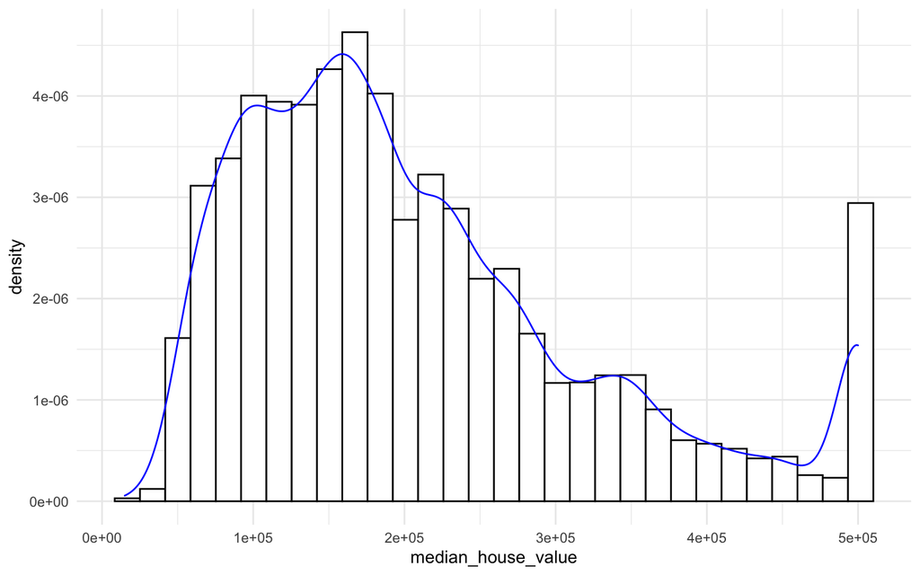

```r
ggplot(dat, aes(x=median_house_value))+
    geom_histogram(aes(y=..density..),
                   col="black",
                   fill="white")+
    geom_density(col="blue")+
    theme_minimal()
```

```r
set.seed(123)
## splitting data
train.id<-createDataPartition(dat$median_house_value,
                              p=0.8,
                              list=FALSE,
                              times=1)
train.dat<-dat[train.id,]
test.dat<-dat[-train.id,]
```

รูปต่อไปนี้เปรียบเทียบการแจกแจงของ median_house_value ระหว่างชุดข้อมูลใหญ่ ชุดข้อมูลฝึกหัด และชุดข้อมูลทดสอบ

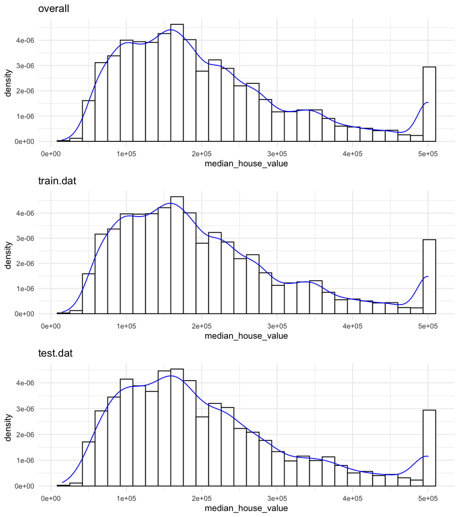

## Stratified Splitting based on Outcome

การสุ่มแบบ simple random sampling สามารถใช้ได้ดีในกรณีที่หน่วยข้อมูลมีความเป็นเอกพันธ์กัน (homogenous) แต่หากหน่วยข้อมูลมีความแตกต่างกันสูง (heterogenous) การสุ่มแบบ SRS อาจไม่สามารถรับประกันได้ว่าจะได้ชุดข้อมูลที่มีลักษณะสอดคล้องกัน

อีกสถานการณ์หนึ่งคือในปัญหา classification ตัวแปรตามที่ใช้ในการวิเคราะห์อาจมีความไม่สมดุลกันในแต่ละ category (imbalance class) เช่น นักเรียนที่คงอยู่ในระบบการศึกษามี 90% ส่วนนักเรียนที่ออกกลางคันจากระบบการศึกษามี 10% การใช้ SRS ในกรณีเช่นนี้อาจทำให้ผู้วิเคราะห์ได้หน่วยข้อมูลที่มีีคุณลักษณะไม่ครบถ้วน

กรณีดังกล่าวการสุ่มตัวอย่างแบบชั้นภูมิอาจให้ชุดข้อมูลฝึกหัดและชุดข้อมูลทดสอบที่มีความเหมาะสมมากกว่า การสุ่มแบบชั้นภูมิใน R สามารถทำได้หลายวิธี วิธีการหนึ่งคือการใช้ฟังก์ชัน `initial_split()` ใน package-rsample ดังตัวอย่างต่อไปนี้

### กรณีตัวแปรตามเป็นตัวแปรต่อเนื่อง

```r
library(rsample)
glimpse(dat)
```

```
## Rows: 20,640
## Columns: 10
## $ longitude          <dbl> -122.23, -122.22, -122.24, -122.25, -122.25, -122.2…
## $ latitude           <dbl> 37.88, 37.86, 37.85, 37.85, 37.85, 37.85, 37.84, 37…
## $ housing_median_age <dbl> 41, 21, 52, 52, 52, 52, 52, 52, 42, 52, 52, 52, 52,…
## $ total_rooms        <dbl> 880, 7099, 1467, 1274, 1627, 919, 2535, 3104, 2555,…
## $ total_bedrooms     <dbl> 129, 1106, 190, 235, 280, 213, 489, 687, 665, 707, …
## $ population         <dbl> 322, 2401, 496, 558, 565, 413, 1094, 1157, 1206, 15…
## $ households         <dbl> 126, 1138, 177, 219, 259, 193, 514, 647, 595, 714, …
## $ median_income      <dbl> 8.3252, 8.3014, 7.2574, 5.6431, 3.8462, 4.0368, 3.6…
## $ median_house_value <dbl> 452600, 358500, 352100, 341300, 342200, 269700, 299…
## $ ocean_proximity    <chr> "NEAR BAY", "NEAR BAY", "NEAR BAY", "NEAR BAY", "NE…
```

```r
set.seed(123)
strat_split<-initial_split(dat,
                        prop=0.8,
                        strata="median_house_value")
str_train<-training(strat_split)
str_test<-testing(strat_split)

summary(str_train$median_house_value)
```

```
##    Min. 1st Qu.  Median    Mean 3rd Qu.    Max.
##   14999  119600  179700  206591  264775  500001
```

```r
summary(str_test$median_house_value)
```

```
##    Min. 1st Qu.  Median    Mean 3rd Qu.    Max.
##   14999  119550  179650  207914  264700  500001
```

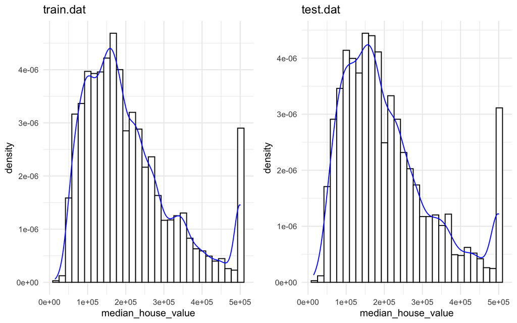

### กรณีตัวแปรตามเป็นตัวแปรจัดประเภท

กรณีที่ตัวแปรตามเป็นตัวแปรจัดประเภท จะสุ่มหน่วยข้อมูลจากแต่ละ category ในตัวแปรตาม โดยใช้สัดส่วนของ category เป็นเกณฑ์

```r
glimpse(iris)
```

```
## Rows: 150
## Columns: 5
## $ Sepal.Length <dbl> 5.1, 4.9, 4.7, 4.6, 5.0, 5.4, 4.6, 5.0, 4.4, 4.9, 5.4, 4.…
## $ Sepal.Width  <dbl> 3.5, 3.0, 3.2, 3.1, 3.6, 3.9, 3.4, 3.4, 2.9, 3.1, 3.7, 3.…
## $ Petal.Length <dbl> 1.4, 1.4, 1.3, 1.5, 1.4, 1.7, 1.4, 1.5, 1.4, 1.5, 1.5, 1.…
## $ Petal.Width  <dbl> 0.2, 0.2, 0.2, 0.2, 0.2, 0.4, 0.3, 0.2, 0.2, 0.1, 0.2, 0.…
## $ Species      <fct> setosa, setosa, setosa, setosa, setosa, setosa, setosa, s…
```

```r
table(iris$Species)
```

```
##
##     setosa versicolor  virginica
##         50         50         50
```

```r
set.seed(123)
strat_split<-initial_split(iris,
                        prop=0.7,
                        strata="Species")
str_train<-training(strat_split)
str_test<-testing(strat_split)

table(str_train$Species)%>%prop.table()
```

```
##
##     setosa versicolor  virginica
##  0.3333333  0.3333333  0.3333333
```

```r
table(str_test$Species)%>%prop.table()
```

```
##
##     setosa versicolor  virginica
##  0.3333333  0.3333333  0.3333333
```

## Splitting Based on the Predictors

การแบ่งข้อมูลลักษณะนี้จะใช้อัลกอริทึม maximum dissimilarity หรือ `maxDissim` (Willett, 1999)กำหนดให้ A เป็นชุดข้อมูลตั้งต้น (initial dataset) ขนาด m หน่วย และ B เป็นชุดข้อมูลรวมขนาด n หน่วย โดยที่ $n > m$

อัลกอริทึม `maxDissim` จะสุ่มเลือกหน่วยข้อมูลใน B โดยพิจารณาให้มีความแตกต่าง (disimilarity) กับหน่วยข้อมูลใน A มากที่สุด

```r
dat.all<-data.frame(scale(iris[,1:4],center=TRUE,scale=TRUE))
glimpse(dat.all)
```

```
## Rows: 150
## Columns: 4
## $ Sepal.Length <dbl> -0.89767388, -1.13920048, -1.38072709, -1.50149039, -1.01…
## $ Sepal.Width  <dbl> 1.01560199, -0.13153881, 0.32731751, 0.09788935, 1.245030…
## $ Petal.Length <dbl> -1.335752, -1.335752, -1.392399, -1.279104, -1.335752, -1…
## $ Petal.Width  <dbl> -1.3110521, -1.3110521, -1.3110521, -1.3110521, -1.311052…
```

```r
set.seed(123)
initial.id<-sample(1:dim(dat.all)[1],5)
A.set<-dat.all[initial.id,] #initial set
B.set<-dat.all[-initial.id,]

## maxDissim dataset
maxdis.dat<-maxDissim(A.set, B.set, n=50)
maxdis.dat<-B.set[maxdis.dat,]
```

รูปต่อไปนี้แสดงการเปรียบเทียบระหว่างชุดข้อมูลรวม ชุดข้อมูลตั้งต้น และชุดข้อมูลที่สุ่มโดยใช้อัลกอริทึม `maxDissim`

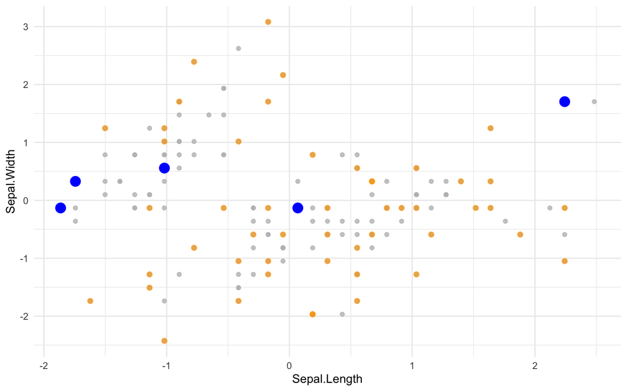

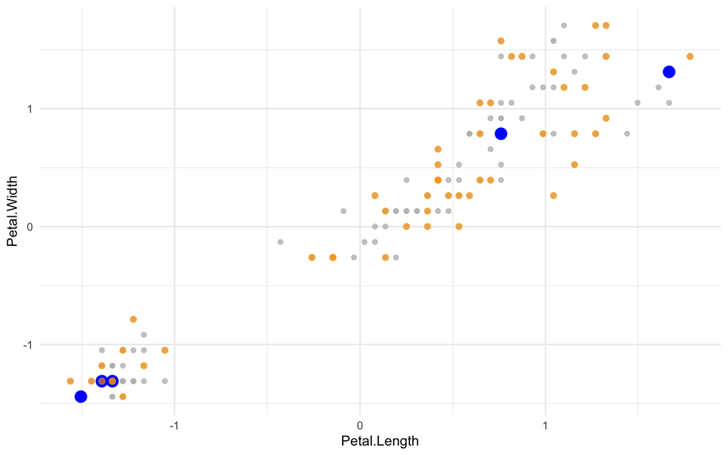

# Class Imbalances Problem

ปัญหาข้อมูลไม่สมดุล (class imbalance problem) เป็นปัญหาที่พบใน classification problem ปัญหานี้เป็นปัญหาสำคัญที่ส่งผลกระทบค่อนข้างรุนแรงต่อประสิทธิภาพในการทำนายของโมเดล

เมื่อเกิดปัญหาข้อมูลไม่สมดุล จำนวนหน่วยข้อมูลใน category ของตัวแปรตามอย่างน้อย 2 category มีความแตกต่างกันมากเกินไป เช่นตัวอย่างชุดข้อมูลต่อไปนี้

```r
dropout<-read.csv("/Users/siwachoat/Library/Mobile Documents/com~apple~CloudDocs/github/2758688 ML/new/week2ML/dropout.csv")
table(dropout$Class)%>%prop.table()
```

```
##
##           0           1
## 0.998272514 0.001727486
```

โดยที่ `class = 1` คือนักเรียนที่ออกกลางคัน

การแก้ปัญหา class imbalances สามารถทำได้หลายวิธีการ วิธีการที่เป็นที่นิยมกันคือ

- up-sampling
- down-sampling
- SMOTE